# exercise-05

Now use the sample_n() or slice_sample() function from {dplyr} to sample ONE subset of 50 zombie apocalypse survivors (without replacement) from this population and calculate the mean and sample standard deviation for each variable. Also estimate the standard error for each variable based on this one sample and use that to construct the theoretical 95% confidence interval for each mean. You can use either the standard normal or a Student’s t distribution to derive the critical values needed to calculate the lower and upper limits of the CI.

```r
#i transpose it into a list in z_sample_list at end of this code block
z_sample = z %>%
  slice_sample(n=50, replace = FALSE) %>%
    summarise(
      #for height
      mean_height = mean(height),
      sd_height =  sd(height),
      se_height = sd_height/sqrt(length(sd_height)),
      CI_lower_height = mean_height + qnorm(0.025)*se_height,
      CI_upper_height = mean_height + qnorm(0.975)*se_height,
      #for weight
      mean_weight = mean(weight),
      sd_weight =  sd(weight),
      se_weight = sd_weight/sqrt(length(sd_weight)),
      CI_lower_weight = mean_weight + qnorm(0.025)*se_weight,
      CI_upper_weight = mean_weight + qnorm(0.975)*se_weight,
      #for age
      mean_age = mean(age),
      sd_age =  sd(age),
      se_age = sd_age/sqrt(length(sd_age)),
      CI_lower_age = mean_age + qnorm(0.025)*se_age,
      CI_upper_age = mean_age + qnorm(0.975)*se_age,
      #for zombies killed
      mean_zombies_killed = mean(zombies_killed),
      sd_zombies_killed =  sd(zombies_killed),
      se_zombies_killed = sd_zombies_killed/sqrt(length(sd_zombies_killed)),
      CI_lower_zombies_killed = mean_zombies_killed + qnorm(0.025)*se_zombies_killed,
      CI_upper_zombies_killed = mean_zombies_killed + qnorm(0.975)*se_zombies_killed,
      #for years of education
      mean_years_of_education = mean(years_of_education),
      sd_years_of_education =  sd(years_of_education),
      se_years_of_education = sd_years_of_education/sqrt(length(sd_years_of_education)),
      CI_lower_years_of_education = mean_years_of_education + qnorm(0.025)*se_years_of_education,
      CI_upper_years_of_education = mean_years_of_education + qnorm(0.975)*se_years_of_education)

z_sample_list = transpose(z_sample)
```

Then draw another 199 random samples of 50 zombie apocalypse survivors out and calculate the mean for each of the these samples. Together with the first sample you drew out, you now have a set of 200 means for each variable (each based on 50 observations), which constitutes a sampling distribution for each variable. What are the means and standard deviations of the sampling distribution for each variable?

```r
#getting 199 more samples and calculating the means and SDs for each variable

reps2 = 199
z_samples_199 = do(reps2) * (z %>%
  slice_sample(n=50, replace = FALSE))

z_samples_199_means = z_samples_199 %>%
  group_by(.index) %>%
  summarise(
          #for height
      mean_height = mean(height),
      sd_height =  sd(height),
      #for weight
      mean_weight = mean(weight),
      sd_weight =  sd(weight),
      #for age
      mean_age = mean(age),
      sd_age =  sd(age),
      #for zombies killed
      mean_zombies_killed = mean(zombies_killed),
      sd_zombies_killed =  sd(zombies_killed),
      #for years of education
      mean_years_of_education = mean(years_of_education),
      sd_years_of_education =  sd(years_of_education)
  )

#combining these 199 samples with the 1 sample in previous code chunk to get means and SDs of each variable for 200 samples

z_sample_200 = z_sample %>%
  mutate(.index = 200) %>%
  select(.index,
         mean_height, sd_height,
         mean_weight, sd_weight,
         mean_age, sd_age,
         mean_zombies_killed, sd_zombies_killed,
         mean_years_of_education, sd_years_of_education
         )
z_samples_all = bind_rows(z_samples_199_means, z_sample_200)

#and now, calculating means and SDs of sampling distribution for each variable

z_sampling_dist = z_samples_all %>%
  summarise(
    #for height
    sampdist_mean_height = mean(mean_height),
    sampdist_sd_height = sd(sd_height),
    #for weight
    sampdist_mean_weight = mean(mean_weight),
    sampdist_sd_weight = sd(sd_weight),
    #for age
    sampdist_mean_age = mean(mean_age),
    sampdist_sd_age = sd(sd_age),
    #for zombies killed
    sampdist_mean_zombies_killed = mean(mean_zombies_killed),
    sampdist_sd_zombies_killed = sd(sd_zombies_killed),
    #for years of education
    sampdist_mean_years_of_education = mean(mean_years_of_education),
    sampdist_sd_years_of_education = sd(sd_years_of_education)
  )
z_samplingdist_list = transpose(z_sampling_dist)
```

Finally, construct a 95% confidence interval for each mean directly from the sampling distribution of sample means using the central 95% that distribution (i.e., by setting the lower and upper CI bounds to 2.5% and 97.5% of the way through that distribution).

```r
z_sampling_dist_CIs = z_sampling_dist %>%
  summarise(
    #for height
    se_height = sampdist_sd_height/sqrt(length(sampdist_sd_height)),
      CI_lower_height = sampdist_mean_height + qnorm(0.025)*se_height,
      CI_upper_height = sampdist_mean_height + qnorm(0.975)*se_height,
    #for weight
        se_weight = sampdist_sd_weight/sqrt(length(sampdist_sd_weight)),
      CI_lower_weight = sampdist_mean_weight + qnorm(0.025)*se_weight,
      CI_upper_weight = sampdist_mean_weight + qnorm(0.975)*se_weight,
    #for age
        se_age = sampdist_sd_age/sqrt(length(sampdist_sd_age)),
      CI_lower_age = sampdist_mean_age + qnorm(0.025)*se_age,
      CI_upper_age = sampdist_mean_age + qnorm(0.975)*se_age,
    #for zombies killed
        se_zombies_killed = sampdist_sd_zombies_killed/sqrt(length(sampdist_sd_zombies_killed)),
      CI_lower_zombies_killed = sampdist_mean_zombies_killed + qnorm(0.025)*se_zombies_killed,
      CI_upper_zombies_killed = sampdist_mean_zombies_killed + qnorm(0.975)*se_zombies_killed,
    #for years of education
        se_years_of_education = sampdist_sd_years_of_education/sqrt(length(sampdist_sd_years_of_education)),
      CI_lower_years_of_education = sampdist_mean_years_of_education + qnorm(0.025)*se_years_of_education,
      CI_upper_years_of_education = sampdist_mean_years_of_education + qnorm(0.975)*se_years_of_education,
  )

z_samplingdist_CIs_list = transpose(z_sampling_dist_CIs)
```

How do the standard deviations of the sampling distribution for each variable compare to the standard errors estimated from your first sample of size 50? The SDs of the sampling distribution are much lower than those of the first sample of 50.

What do sampling distributions for each variable mean look like? Are they normally distributed?

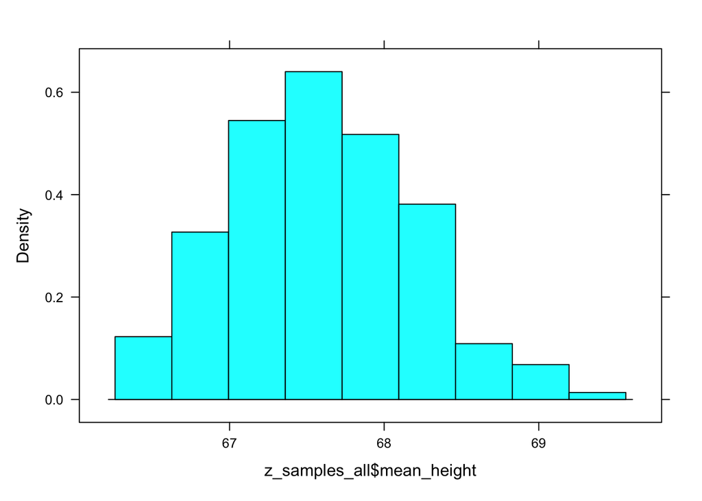

```r
histogram(z_samples_all$mean_height)
```

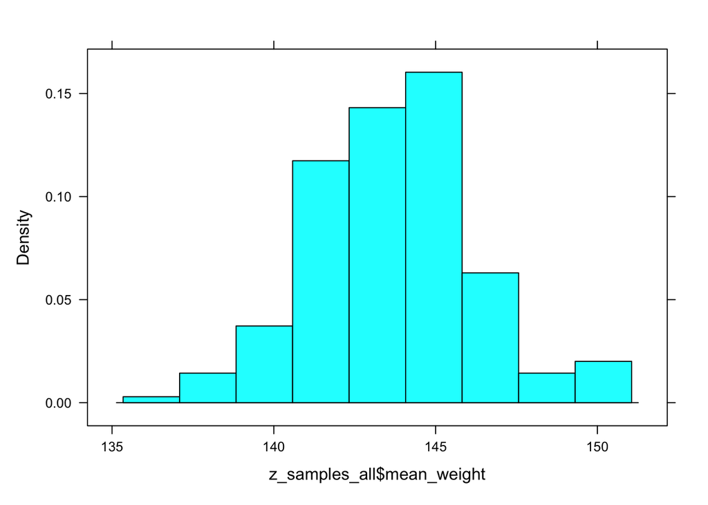

```r
histogram(z_samples_all$mean_weight)
```

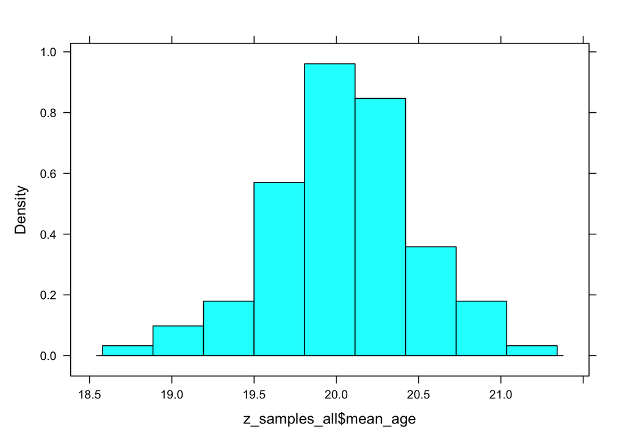

```r
histogram(z_samples_all$mean_age)
```

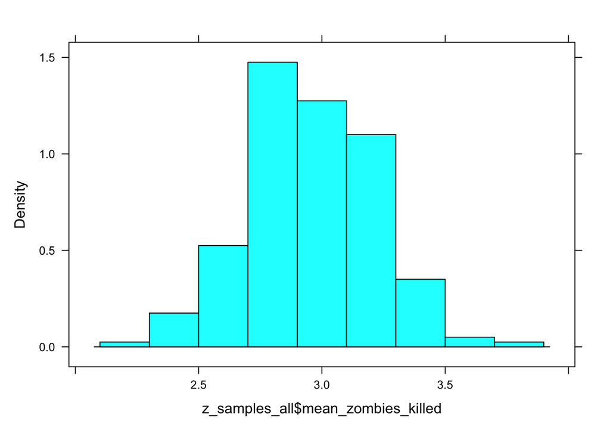

```r
histogram(z_samples_all$mean_zombies_killed)
```

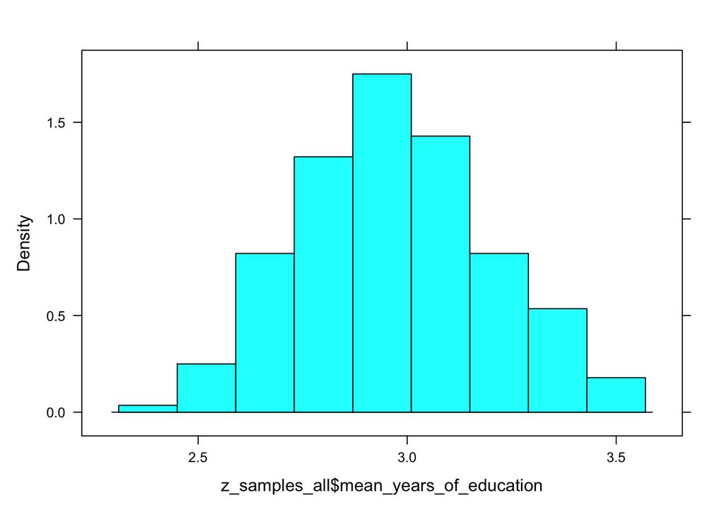

```r
histogram(z_samples_all$mean_years_of_education)
```

What about for those variables that you concluded were not originally drawn from a normal distribution? How do the two 95% CIs you estimated compare to one another (i.e., the CI based on one sample and the corresponding sample standard deviation versus the CI based on simulation where you created a sampling distribution across 200 samples)?